# Session 08 Tree-Based Models

[**CCMVI2085U Machine Learning for Predictive Analytics in Business @ CBS ISUP 2020**](https://kursuskatalog.cbs.dk/2019-2020/KAN-CCMVI2085U.aspx?lang=en-GB)

Course coordinator: [Bowei Chen](https://boweichen.github.io/) | Email: bc.acc@cbs.dk

# Table of Contents

## Decision trees

### What is a decision tree?

[figure not shown]

[figure not shown]

[figure not shown]

A **tree** is a directed, connected graph with one **root node**. Every other node has a single predecessor (parent) and no or more successors (children). Nodes without successors are called **leaves**. All nodes are connected by **edges**. The **depth of a node** is the number of edges on the path to the root. The **height of the whole tree** is the number of edges on the longest path from the root to any leaf.

| Tree | Decision tree equivalent |
| --- | --- |
| Root | Initial decision node |
| Node | Internal decision node for testing on an attribute |
| Edge | Rule to follow |
| Leaf | Terminal node represents the resulting classification |

### if-else statement

Maybe solving this problem graphically is a better idea. So we can draw a node for each question and an edge for each answer.

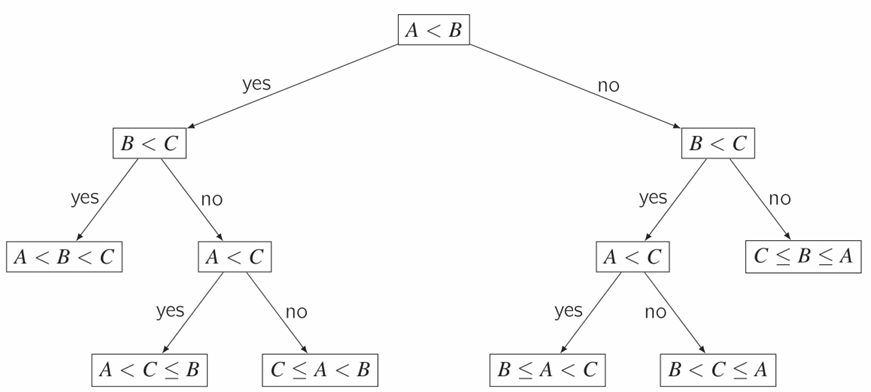

For the above tree, we can easily write a Python function to implement this tree for decision making. As shown in the function below, the Python if-else syntax implies the tree structure in a vertical form and we get six rules for $3!= 6$ different combinations.

```
def sort1(A, B, C):
    if A < B:
        if B < C:
            return [A, B, C]
        else:
            if A < C:
                return [A, C, B]
            else:
                return [C, A, B]
    else:
        if B < C:
            if A < C:
                return [B, A, C]
            else:
                return [B, C, A]
        else:
            return [C, B, A]

print(sort1(9, -2, 0))  # >> [-2, 0, 9]
print(sort1(2, 0, 0))  # >> [0, 0, 2]
```

**Dataset for the sorting example**

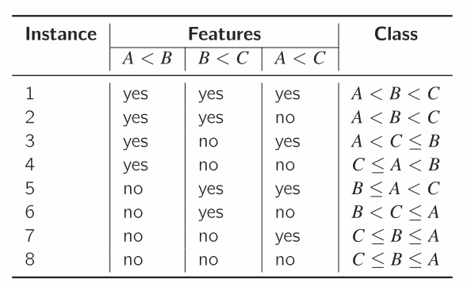

- The input of a machine learning algorithm consists of a set of **instances** (e.g. rows, examples or observations).
- Each instance is described by a fixed number of **attributes** or **features** (i.e. columns), which are assumed to be either nominal or numeric.
- Each instance has a label which is called **class** (in case of a classification task).
- The set of all instances is called **dataset**.

### Black box vs. white box

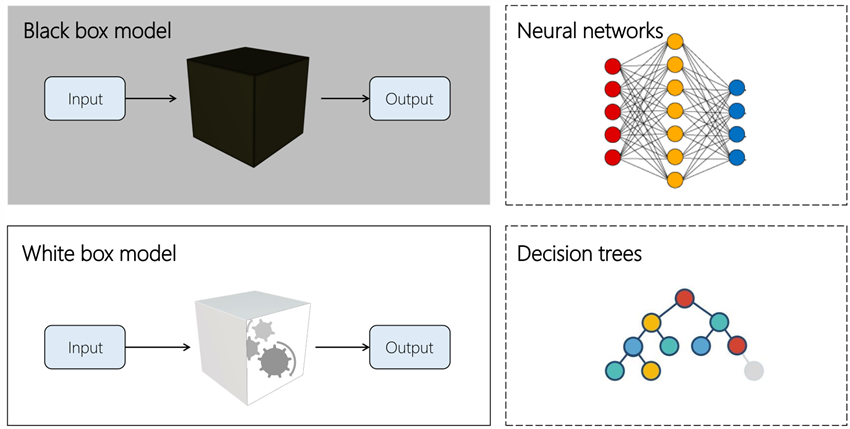

### Basic algorithms for decision tree learning

To illustrate decision tree learning. Let's look at the following toy example.

A car finance company receives applications for car loans. Each application contains the information about an applicant:

- age
- professional status
- property
- credit rating
- ...

The company needs to decide whether an application should be approved or not.

The following is the small dataset we have. There are 15 instances and the response/label is `Class`.

|  | Age | Has_Job | Own_House | Credit_Rating | Class |
| --- | --- | --- | --- | --- | --- |
| 0 | young | False | False | fair | No |
| 1 | young | False | False | good | No |
| 2 | young | True | False | good | Yes |
| 3 | young | True | True | fair | Yes |
| 4 | young | False | False | fair | No |
| 5 | middle | False | False | fair | No |
| 6 | middle | False | False | good | No |
| 7 | middle | True | True | good | Yes |
| 8 | middle | False | True | excellent | Yes |
| 9 | middle | False | True | excellent | Yes |
| 10 | old | False | True | excellent | Yes |
| 11 | old | False | True | good | Yes |
| 12 | old | True | False | good | Yes |
| 13 | old | True | False | excellent | Yes |
| 14 | old | False | False | fair | No |

We can have four possible roots to develop a decision tree, which one is better?

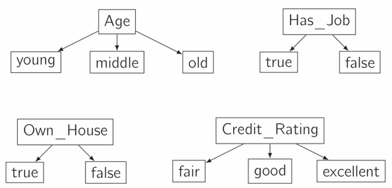

Here we can use an impurity function to develop the tree and split the node. The existing popular decision tree algorithms use different impurity functions:

- Classification and Regression Tree (in short CART) (Breiman et al 1984) uses Gini impurity;
- ID3 (Quinlan 1986) uses information gain based on entropy;
- C4.5 (Quinlan 1993) uses in the information gain ratio based on entropy.

**Informaiton entropy** (or simply **entropy**) measures the amount of disorder or uncertainty in a system. For a given dataset $\mathscr{D}$ with a set of labelled points, the entropy is defined as follows: $$ H(\mathscr{D}) = -\sum_{n=1}^{N} p_k \log_2\{p_k\}, $$ where $p_k = \mathbb{P}(y = c_k \mid \mathscr{D})$ is the probability of class $c_k$ in dataset $\mathscr{D}$, and $K$ is the number of classes so $k = 1, \ldots, K$.

If a region is pure, that is, has points from the same class, then the entropy is zero. On the other hand, if the classes are all mixed up, and each appears with equal probability $p_k = 1/K$, then the entropy has the highest value $H(\mathscr{D}) = \log_2\{K\}$.

The entropy of the car loan dataset can be calculated as follows:

$$ H(\mathscr{D}) = -\frac{9}{15} \log_2\left\{\frac{9}{15}\right\} -\frac{6}{15} \log_2\left\{\frac{6}{15}\right\} = 0.971 $$

The data $\mathscr{D}$ is split based on the value of feature/attribute $A$. To investigate if the split results in a reduced entropy, the **information gain** is defined as follows: $$ G(\mathscr{D}, A) = H(\mathscr{D}) - H(\mathscr{D}\mid A), $$ where $H(\mathscr{D} \mid A)$ is called the **conditional entropy**, given by $$ H(\mathscr{D} \mid A) = - \sum_{n=1}^N \mathbb{P}(A = a_n) H(\mathscr{D} \mid A=a_n), $$ and $N = |\mathscr{D}|$ is the number of instances/observations in $\mathscr{D}$, and $$\sum_{n=1}^N \mathbb{P}(A = a_n) = 1.$$

**The higher the information gain, the more the reduction in entropy, and the better the split point**. Therefore, given split points and their corresponding partitions, we can score each split point and choose the one that gives the highest information gain.

Let $A_1, A_2, A_3, A_4$ denote the features `Age`, `Has_Job`, `Own_House`, and `Credit_Rating`, respectively. Then the information gain from $A_1$ can be calculated as follows:

\begin{align*} G(\mathscr{D}, A_1) = & \ H(\mathscr{D}) - \bigg[\frac{5}{15} H(\mathscr{D}_1) + \frac{5}{15} H(\mathscr{D}_2) + \frac{5}{15} H(\mathscr{D}_3)\bigg] \\ = & \ 0.971 - \bigg[\frac{5}{15} \bigg( -\frac{2}{5} \log_2\left\{\frac{2}{5}\right\} -\frac{3}{5} \log_2\left\{\frac{3}{5}\right\} \bigg) \\ & + \frac{5}{15} \bigg( -\frac{3}{5} \log_2\left\{\frac{3}{5}\right\} -\frac{2}{5} \log_2\left\{\frac{2}{5}\right\} \bigg) + \frac{5}{15} \bigg( -\frac{4}{5} \log_2\left\{\frac{4}{5}\right\} -\frac{1}{5} \log_2\left\{\frac{1}{5}\right\} \bigg)\bigg] \\ = & \ 0.971 - 0.888 = 0.083. \end{align*}

Here $\mathscr{D}_1, \mathscr{D}_2, \mathscr{D}_3$ are the subset of the data where $A_1$ feature takes `young`, `middle`, and `old`, respectively. Following the same way, we can calculate the information gain from $A_2, A_3, A_4$:

$$G(\mathscr{D}, A_2) = 0.324, G(\mathscr{D}, A_3) = 0.420, G(\mathscr{D}, A_4) = 0.363.$$

Therefore, feature `Own_House` is the best choice for the root.

Since feature `Own_House` has been used for the root, we can split the dataset $\mathscr{D}$ into two datasets based on the values of `Own_House`: $\mathscr{D}_1$ for true and $\mathscr{D}_2$ for false. For $\mathscr{D}_1$, all the true instances has the label value Yes. Therefore, it can be the leaf of the tree. For $\mathscr{D}_2$, we can further calculate the information gain from $A_1, A_2, A_4$:.

\begin{align*} G(\mathscr{D}_2, A_1) & \ = H(\mathscr{D}_2) - H(\mathscr{D}_2 \mid A_1) = 0.251, \\ G(\mathscr{D}_2, A_2) & \ = H(\mathscr{D}_2) - H(\mathscr{D}_2 \mid A_2) = 0.918, \\ G(\mathscr{D}_2, A_4) & \ = H(\mathscr{D}_2) - H(\mathscr{D}_2 \mid A_4) = 0.474. \end{align*}

Therefore, feature `Has_Job` is the best choice for the node.

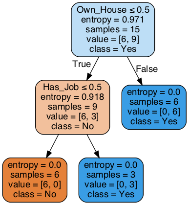

We can also use Gini impurity and can build up a same tree as below. Here Gini impurity is calculated by

$$ I_{G}(p) = 1 - \sum^{K}_{k=1} {p_k}^{2}, $$

where $p_k = \mathbb{P}(y = c_k \mid \mathscr{D})$ is the probability of class $c_k$ in dataset $\mathscr{D}$, and $K$ is the number of classes so $k = 1, \ldots, K$.

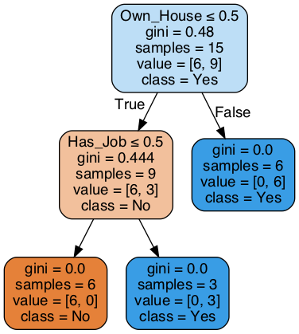

Generally speaking, decision tree is a greedy divide-and-conquer algorithm:

- Tree is constructed in a top-down recursive manner
- At start, all the training examples are at the root
- Instances are partitioned recursively based on selected attributes/variables/features
- Attributes are selected on the basis of an impurity function (e.g., information gain)

Conditions for stopping partitioning

- All examples for a given node belong to the same class
- There are no remaining attributes for further partitioning -- majority class is the leaf
- There are no instances left

### Implementing decision tree in Python

We can use the `scikit-learn` library to implement a decision tree for classifciation through its `DecisionTreeClassifier` class

class sklearn.tree.DecisionTreeClassifier(*, criterion='gini', splitter='best', max_depth=None, min_samples_split=2, min_samples_leaf=1, min_weight_fraction_leaf=0.0, max_features=None, random_state=None, max_leaf_nodes=None, min_impurity_decrease=0.0, min_impurity_split=None, class_weight=None, presort='deprecated', ccp_alpha=0.0)

https://scikit-learn.org/stable/modules/generated/sklearn.tree.DecisionTreeClassifier.html

Let's first prepare the data

```
from sklearn import preprocessing

df_2 = df.copy()
le = preprocessing.LabelEncoder()
col_select_category = df_2.select_dtypes(include=["bool", "object"]).columns

for col in col_select_category:
    le.fit(df_2[col].unique())
    df_2[col] = le.transform(df_2[col].to_numpy())
    if col == "Class":
        label_names = le.classes_

x = df_2[df_2.columns[0:4]].to_numpy()
y = df_2[df_2.columns[-1]].to_numpy()
```

We then train a decision tree classifier using entropy as the impurity function.

```
from sklearn.tree import DecisionTreeClassifier
dtc = DecisionTreeClassifier(criterion="entropy")
dtc.fit(x, y)
```

We can use `export_graphviz` to generate tree graph

```
from sklearn.tree import export_graphviz
import pydotplus
from IPython.display import Image

dot_data = export_graphviz(
    dtc,
    out_file=None,
    feature_names=col_select_category[0:-1],
    class_names=label_names,
    filled=True,
    rounded=True,
    special_characters=True,
)

# Draw graph
graph = pydotplus.graph_from_dot_data(dot_data)

# Show graph
Image(graph.create_png())
```

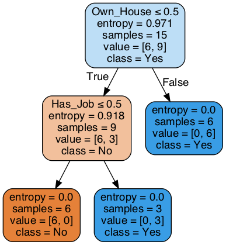

We can use `DecisionTreeRegressor` from the `scikit-learn` library to implement a decision tree for regression.

class sklearn.tree.DecisionTreeRegressor(*, criterion='mse', splitter='best', max_depth=None, min_samples_split=2, min_samples_leaf=1, min_weight_fraction_leaf=0.0, max_features=None, random_state=None, max_leaf_nodes=None, min_impurity_decrease=0.0, min_impurity_split=None, presort='deprecated', ccp_alpha=0.0)

https://scikit-learn.org/stable/modules/generated/sklearn.tree.DecisionTreeRegressor.html

## Ensemble learning

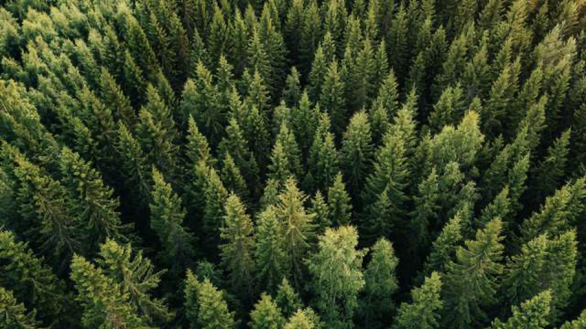

**Ensemble learning** (also called **committee-based learning**) is a subfield of machine learning. The idea is to train multiple learners/models to solve the same problem. In contrast to ordinary learning approaches which try to construct one learner/model from training data, ensemble learning tries to construct a set of learners (called **base learners**) and combine them.

There are two popular ensemble learning methods: **bootstrap aggregation** (in short **bagging**) and **boosting**.

### Bootstrap aggregation

**Bootstrap aggregation** (in short **bagging**) is an ensemble method where the base learners are generated in parallel. The basic motivation is to exploit the independence between the base learners, since the error can be reduced dramatically by combining independent base learners. The following algorithm represent the basic idea of bagging:

**Input**: $\mathscr{D} = \{(\boldsymbol{x}_1, y_1), (\boldsymbol{x}_2, y_2), \ldots, (\boldsymbol{x}_N, y_N)\}$  
Base learning algorithm $f$  
Number of base learners $T$  
**Process**:  
1: **for** $t = 1, \ldots, T$:  
2: **Train** a learner $h_t = f(\mathscr{D}_{bs})$ # $\mathscr{D}_{bs}$ is the bootstrap distribution from $\mathscr{D}$  
**Output**: $\text{argmax}_{y \in \mathcal{Y}} \sum_{t=1}^{T} \mathbb{I}(h_t(\boldsymbol{x})=y)$

**Random forest** [Breiman, 2001] is a representative of the state-of-the-art bagging algorithm. It incorporates of randomized feature selection when constructing decision trees. Random forest first randomly selects a subset of features, and then carries out the conventional split selection procedure within the selected feature subset.

### Boosting

**Boosting** is sequential ensemble method where the base learners are generated sequentially. The basic motivation of sequential methods is to exploit the dependence between the base learners, since the overall performance can be boosted in a residual-decreasing way. The following algorithm represent the general boosting procedure:

**Input**: $\mathscr{D} = \{(\boldsymbol{x}_1, y_1), (\boldsymbol{x}_2, y_2), \ldots, (\boldsymbol{x}_N, y_N)\}$  
Base learning algorithm $f$  
Number of learning rounds $T$  
**Process**:  
1: **Initialize distribution** $\mathscr{D}_1 = \mathscr{D}$  
2: **for** $t = 1, \ldots, T$:  
3: **Train** a base learner $h_t = f(\mathscr{D}_{t})$ from distribution $\mathscr{D}_{t}$  
4: **Evaluate** the error $\epsilon_t$ of $h_t$  
5: **Adjust** distribution $\mathscr{D}_{t+1}$ by considering the error $\epsilon_t$  
**Output**: $\text{Combine_Outputs}(\{h_1(\boldsymbol{x}), \ldots, h_T(\boldsymbol{x})\})$

**AdaBoost** and **gradient boosting** are two representatives of boosting algorithms.

- For AdaBoost, in every step of the sequential training, the sample distribution is adapted to have more weight on misclassified samples and less weight on correctly classified samples. Also, the final prediction is a weighted average of all base learners, with more weight on the later learners. You could understand that the shortcomings/problems are identified/improved by high-weight data points in Adaboost
- For gradient boosting, the boosting process is considered as an optimization algorithm. Therefore, gradient boosting optimizes a cost function by iteratively choosing a function that data samples in the negative gradient direction. You could understand that the shortcomings/problems are identified/improved by gradient decents.

### Implementation of random forest, adaboost and gradient boosting in Python

We can implement these ensemble methods using the following classes from `sklearn`:

Random forest:

- `RandomForestClassifier` (for classification) https://scikit-learn.org/stable/modules/generated/sklearn.ensemble.RandomForestClassifier.html
- `RandomForestRegressor` (for regression) https://scikit-learn.org/stable/modules/generated/sklearn.ensemble.RandomForestRegressor.html

AdaBoost:

- `AdaBoostClassifier` (for classification) https://scikit-learn.org/stable/modules/generated/sklearn.ensemble.AdaBoostClassifier.html
- `AdaBoostRegressor` (for regression) https://scikit-learn.org/stable/modules/generated/sklearn.ensemble.AdaBoostRegressor.html

Gradient boosting

- `GradientBoostingClassifier` (for classification) https://scikit-learn.org/stable/modules/generated/sklearn.ensemble.GradientBoostingClassifier.html
- `GradientBoostingRegressor` (for regression) https://scikit-learn.org/stable/modules/generated/sklearn.ensemble.GradientBoostingRegressor.html

In the following I show a simple example of implementing a random forest with the car loan example. More examples of tree-based models implementation and comparison will be given in the workshop session.

```
from sklearn.ensemble import RandomForestClassifier

rfc = RandomForestClassifier(n_estimators=10, criterion="entropy")
rfc.fit(x, y)
```

```
RandomForestClassifier(bootstrap=True, ccp_alpha=0.0, class_weight=None,
                       criterion='entropy', max_depth=None, max_features='auto',
                       max_leaf_nodes=None, max_samples=None,
                       min_impurity_decrease=0.0, min_impurity_split=None,
                       min_samples_leaf=1, min_samples_split=2,
                       min_weight_fraction_leaf=0.0, n_estimators=10,
                       n_jobs=None, oob_score=False, random_state=None,
                       verbose=0, warm_start=False)
```

Here I visualise the first tree

```
est = rfc.estimators_[0]
dot_data = export_graphviz(
    est,
    out_file=None,
    feature_names=col_select_category[0:-1],
    class_names=label_names,
    filled=True,
    rounded=True,
    special_characters=True,
)
graph = pydotplus.graph_from_dot_data(dot_data)
Image(graph.create_png())
```

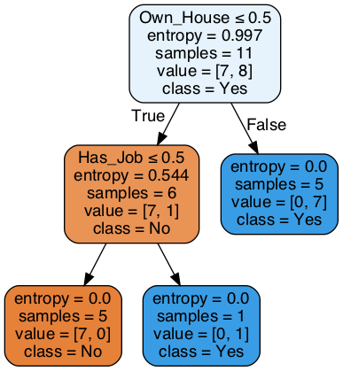

```
est = rfc.estimators_[2]
dot_data = export_graphviz(
    est,
    out_file=None,
    feature_names=col_select_category[0:-1],
    class_names=label_names,
    filled=True,
    rounded=True,
    special_characters=True,
)
graph = pydotplus.graph_from_dot_data(dot_data)
Image(graph.create_png())
```

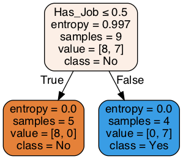

### Discussion

- Ensemble models are not universally better than their single counterparts, they are better only if the single models suffer of instability. If the predictions of the trees are stable, all base learners return the same predictions and then the predictions of ensemble models are just the same as the predictions of each single tree.
- In theory, boosting methods are slightly better than bagging methods mainly because base learners improve over the iterations. However, this depends on parameters tuning. From another aspect, training bagging methods can be slightly faster than boosting methods.